# Homework #2

## Describing data using graphics

The following exercises use a data set called `diamonds`, which can be found in the `ggplot2` package. You can load it in with the following code.

```r
require(ggplot2)
data(diamonds)
```

1. How many observations (rows) are there in this data set? What does each row represent?

SOLUTION:

There are 53940 rows in this data set, where each row refers to a different diamond (see ?diamonds for more details).

2. Consider the `cut` of these diamonds. Where does this variable fall in the taxonomy of data? Please create a graphic of its distribution and describe it in words.

SOLUTION:

`cut` is a categorical variable with a distribution that can be visualized using a barplot.

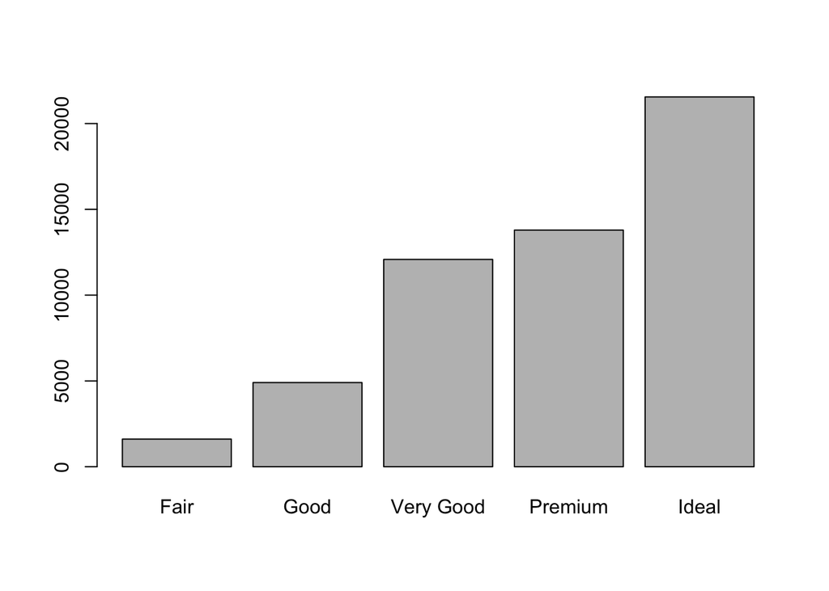

```r
barplot(table(diamonds$cut))
```

The most common cut in this data set is “ideal” and the distribution is skewed-left towards the less-desirable cuts.

3. Next please address the same questions for the `price` variable.

SOLUTION:

`price` can be considered as a continuous numerical variable, with a distribution that can be visualized with a histogram or a density plot (we show the latter).

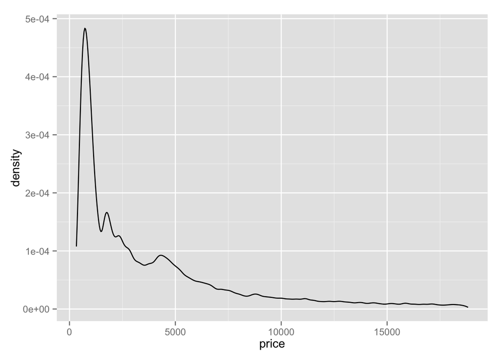

```r
qplot(data=diamonds, x=price, geom="line", stat="density", adjust=0.4)
```

The median price is 2401 and the distribution is skewed to the right, with comparatively few expensive diamonds.

4. What is the average `price` of diamonds that are of `Good` cut? What about `Very Good`?

SOLUTION:

The mean price of diamonds of good cut is 3928.8645, while the mean of the very good cut is 3981.7599. Since the distribution of price within each group is right-skewed, it may be more meaningful to compare the medians, which are 3050.5 for good diamonds and 2648 for very good (note that the price ranks change with the selection of what we mean by “average”).

5. What would you expect to be the relationship between `cut` and `price`? Please create the appropriate graphic to visualize this relationship and describe its structure.

SOLUTION:

We would expect that as the cut of a diamond increases in grade, that the price would increase corresondingly. We can visualize their relationship be constructing side-by-side boxplots.

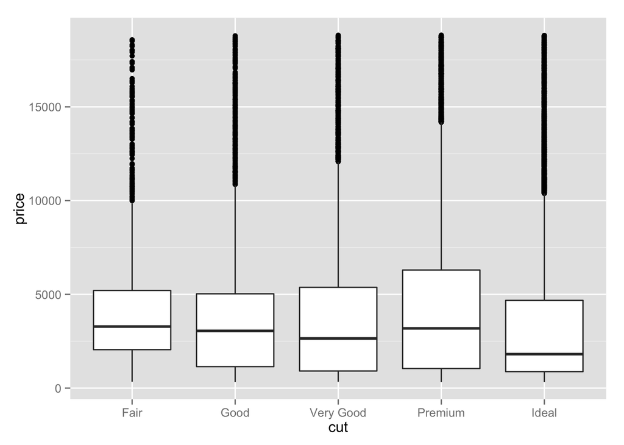

As it turns out, when comparing the medians, the typical ideal diamond is less expensive than any of the other grades. This doesn’t seem to make sense! Regarding the shape of the price distribution within each cut category, they all have similar right-skews.

6. What would you expect to be the relationship between `carat` and `price`? Please create the appropriate graphic to visualize this relationship and describe its structure.

SOLUTION:

We would expect that price to increase as the carat increases, as carat corresponds to the size of the diamond. We can visualize their relationship with a scatterplot.

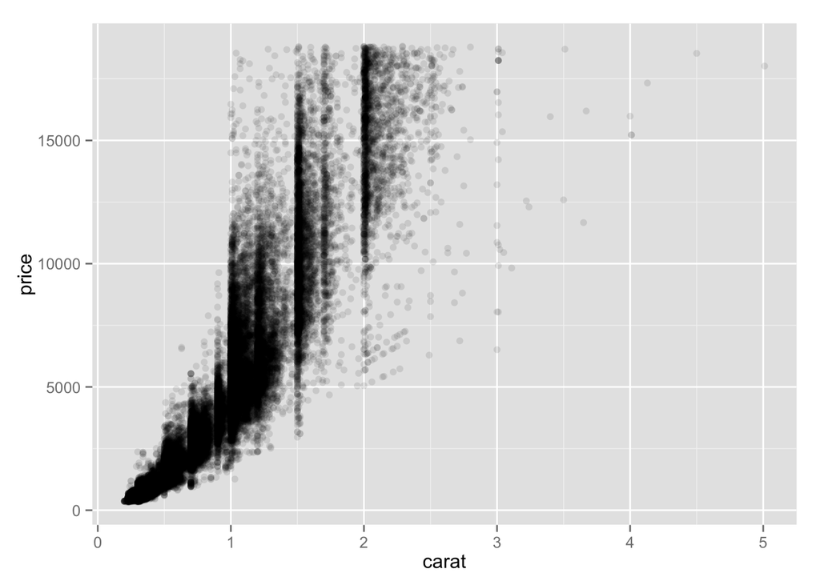

Sure enough, the two variables have a positive relationship. The trend doesn’t appear to be quite linear: the slope increases as carat increases. Some transparency has been added to control for overplotting. The vertical banding suggests that many diamonds are sized to be at a whole carat or just above. The trend between carat and price is fairly strong, however as magnitudes increase, so does the variation.

7. When comparing diamonds of the same `carat`, what is the relationship between `cut` and `price`? Please create the appropriate plot and interpret it.

SOLUTION:

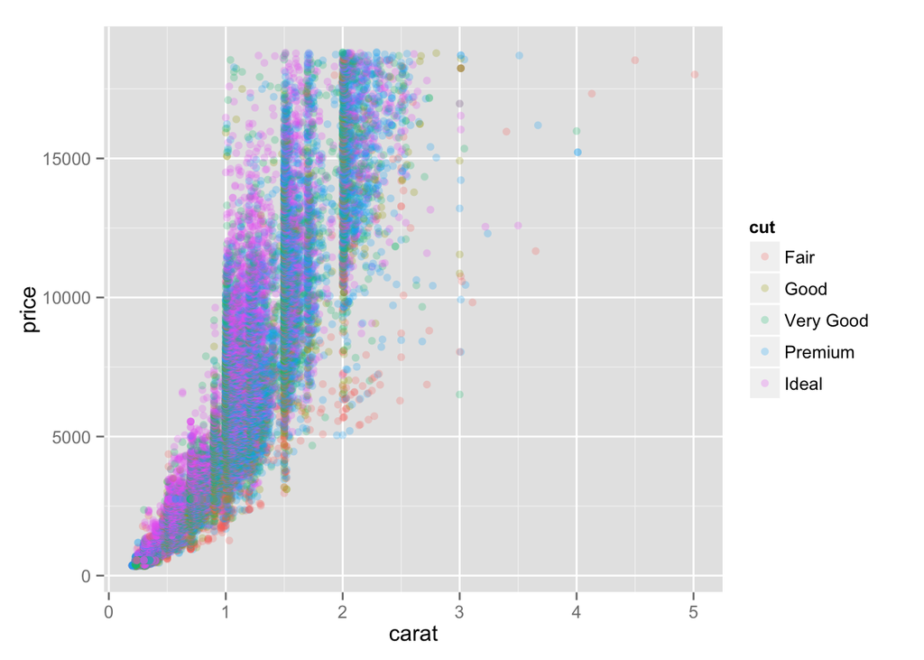

```r
ggplot(data=diamonds, aes(x=carat, y=price)) +
  geom_point(alpha = 1/4) +
  aes(colour=cut)
```

The scatterplot above shows the relationships between carat and price with the observations colored according to their cut. Transparency has been added to address overplotting. If we consider any vertical slice of this scatterplot, the distribution of price appears to increase as the cut quality increases.

We can visualize this more directly by using side-by-side box plots to compare the price distribution of the different cuts are two different carat grades. Below we plot the relationship amongst diamonds of approximately .5 carats.

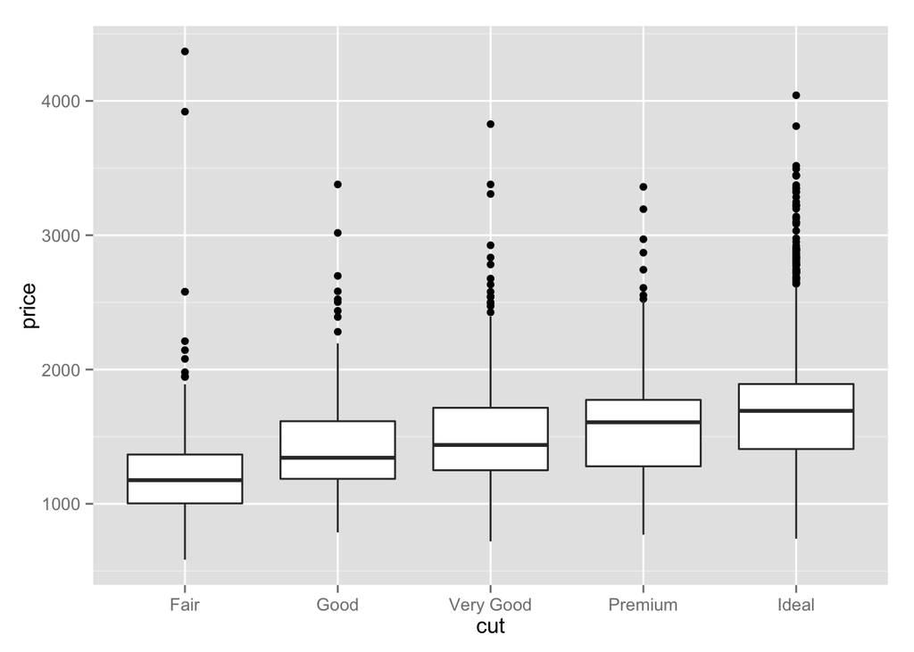

```r
dp5 <- diamonds[diamonds$carat < .55 & diamonds$carat > .45, ]
ggplot(data=dp5, aes(x=cut, y=price)) +
  geom_boxplot()
```

We see that all of the distributions are right skewed and that the median price *increases* with increasing cut quality. A similar structure is seem if we just look at the diamonds that are approximately 1.5 carats.

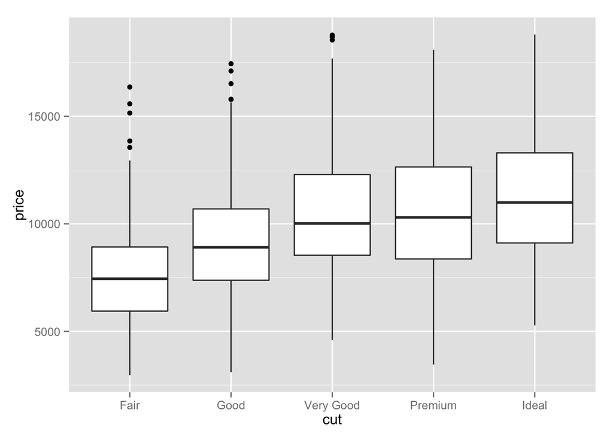

```r
d1p5 <- diamonds[diamonds$carat < 1.55 & diamonds$carat > 1.45, ]
ggplot(data=d1p5, aes(x=cut, y=price)) +
  geom_boxplot()
```

The price distributions have shifted right across all cuts, but the trend between the median prices and cut quality is the same.

That this is a startling finding in light of what we got for number 5! This is best explained by noting that most of the higher grade diamonds are smaller (of lower carat), and to see that relationship between cut quality and price, we need to be sure to compare diamonds of the same size.

8. When comparing diamonds of the same `cut`, what is the relationship between `carat` and `price`? Please create the appropriate plot and interpret it.

SOLUTION:

We can compare diamonds of the same cut by creating different facets for each category.

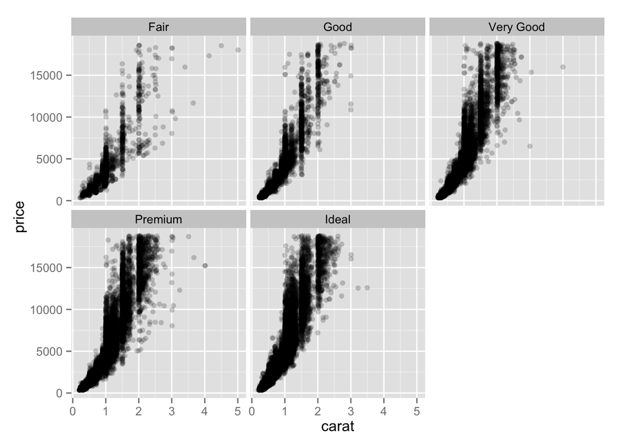

There is a similar relationship between carat and price within each category, showing a linear or super-linear trend within increasing variance as magnitude increases. The relationships appear to differ, though, in that as the cut increases, the slope of the trend line also increases. Said another way, the price of ideal diamonds is more responsive to carat than that of lower-grade diamonds.

## Data Visualization done right and wrong

Please identify two data visualizations that appear in a published scientific journal (e.g. Science, Nature, New England Journal of Medicine). The first graphic should be one that strikes you as well done and the second as poorly constructed. Please comment on the reason for your selections, what they are trying to display, and what sort of graphic is being employed.

To submit these graphics, the easiest way will probably be to bring the graphic up on your computer and take a screenshot. You can then link to them (.jpg, .png, .gif are all good) using markdown syntax (for the reference guide, click the `?` at the top of the markdown editor). When you submit this .Rmd on moodle, you will also have to include both of those image files.